# Time Series Forecasting UK CPIH Inflation Rate With ARIMA

Doualeh Dahir

24/10/2023

## 1. Introduction

Inflation, as a metric, serves as a vital barometer for the economic health of a country. Tracking and forecasting inflation is essential for both policymakers and investors, as it can indicate the future direction of monetary policy and provide insights into the economic environment. The purpose of this analysis is to forecast the UK 12 Month CPIH rate over the next year using historical data.

## 2. Methodology

Time series forecasting is a technique to predict future values based on previously observed values. In this analysis, I used the ARIMA (AutoRegressive Integrated Moving Average), which captures various structures of time series data. The `auto.arima()` function from the `forecast` package in R was utilized, allowing for automatic selection of the best fit ARIMA model based on the historical data.

## Loading Data

```r
library(readr)
ons_data <- read_csv("C:\\Users\\Doualeh\\Downloads\\R ONS Project\\ons_data.csv")
```

## Cleaning Data

Extracting Year and Month from the ‘date’ column.

```r
ons_data$year <- as.numeric(substr(ons_data$date, 1, 4))
month.name <- c("JAN", "FEB", "MAR", "APR", "MAY", "JUN", "JUL", "AUG", "SEP", "OCT", "NOV", "DEC")
ons_data$month_num <- match(substr(ons_data$date, 6, 8), month.name)
```

## Converting Data to Time Series Format

```r
ts_data <- ts(ons_data$inflation_rate, start=c(min(ons_data$year), min(ons_data$month_num)), frequency=12)
```

## Visualising Time Series

[figure not shown]

## 3. Time Series Trends

Our data runs from January 1989-September 2023. From the above plot, we can observe high CPIH in the early 90’s (peaking at 9.2% in September 1990).

CPIH then falls and remains at low levels for the next ~ 30 years. CPI then begins to climb, peaking at 9.6% in October 2022. In the 12 months to September 2023, it sits at 6.3%.

## Determining ARIMA Model

```r
library(forecast)
arima_model <- auto.arima(ts_data)
```

## Forecasting

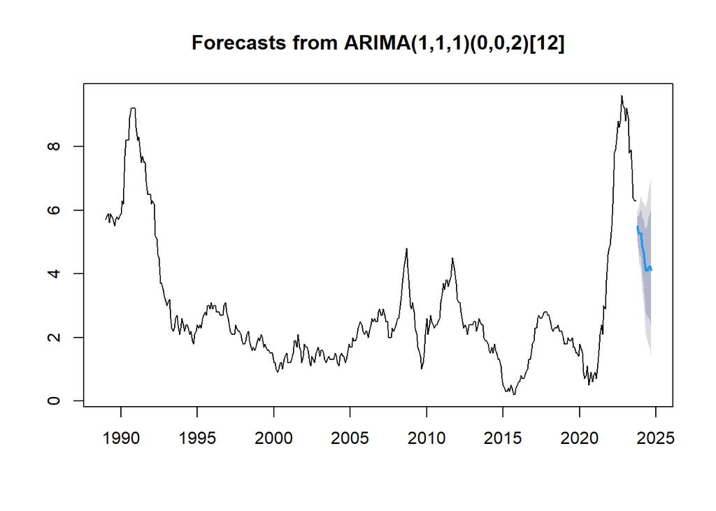

## Viewing Forecast Data

|  | Point Forecast | Lo 80 | Hi 80 | Lo 95 | Hi 95 |
| --- | --- | --- | --- | --- | --- |
| Oct 2023 | 5.490062 | 5.179241 | 5.800882 | 5.014703 | 5.965421 |
| Nov 2023 | 5.314939 | 4.840690 | 5.789187 | 4.589638 | 6.040239 |
| Dec 2023 | 5.249006 | 4.627157 | 5.870856 | 4.297969 | 6.200043 |
| Jan 2024 | 5.269886 | 4.506288 | 6.033483 | 4.102064 | 6.437708 |
| Feb 2024 | 4.879076 | 3.976507 | 5.781644 | 3.498716 | 6.259435 |
| Mar 2024 | 4.660107 | 3.620175 | 5.700040 | 3.069668 | 6.250547 |
| Apr 2024 | 4.317589 | 3.141441 | 5.493737 | 2.518826 | 6.116352 |
| May 2024 | 4.101062 | 2.789692 | 5.412432 | 2.095495 | 6.106629 |
| Jun 2024 | 4.096031 | 2.650416 | 5.541645 | 1.885154 | 6.306908 |
| Jul 2024 | 4.200047 | 2.621212 | 5.778883 | 1.785426 | 6.614668 |
| Aug 2024 | 4.233969 | 2.523007 | 5.944931 | 1.617279 | 6.850659 |
| Sep 2024 | 4.121296 | 2.279383 | 5.963209 | 1.304332 | 6.938260 |

## 5. Discussion

Based on the forecast, it is projected that the UK’s CPI will see a decline throughout 2024. This downward trend could signify an easing of inflationary pressures on the UK economy, possibly due to effective policy interventions or natural economic adjustments. If this forecast holds true, consumers might experience a decrease in the rate at which prices for goods and services increase, benefiting their purchasing power.

However, it’s essential to note the limitations of the ARIMA model. While the model uses past data to predict future trends, it may not account for unforeseen economic shocks, such as global recessions, pandemics, or geopolitical events. Additionally, external factors not present in the historical data, like new fiscal policies or global economic shifts, could also influence the actual inflation rates.

## 6. Conclusion

Historical CPIH data shows significant fluctuations, with peaks in the early ’90s and in 2022.

Notably, the UK’s inflation rate was relatively stable from the mid-90s to around 2021, with most of the values fluctuating below 3%. Starting from 2021, there’s a pronounced rise in the inflation rate, with it peaking at 9.6% in October 2022.

The 2024 forecast hints at potential economic stabilization.

Future research could benefit from exploring diverse forecasting methods and incorporating broader economic indicators for a holistic view.

## 7. References

Data Source: [ONS Statistics](https://www.ons.gov.uk/economy/inflationandpriceindices/timeseries/l55o/mm23)